# **Project: Amazon Product Recommendation System**

# **Marks: 40**

Welcome to the project on Recommendation Systems. We will work with the Amazon product reviews dataset for this project. The dataset contains ratings of different electronic products. It does not include information about the products or reviews to avoid bias while building the model.

## **Context:**

Today, information is growing exponentially with volume, velocity and variety throughout the globe. This has lead to information overload, and too many choices for the consumer of any business. It represents a real dilemma for these consumers and they often turn to denial. Recommender Systems are one of the best tools that help recommending products to consumers while they are browsing online. Providing personalized recommendations which is most relevant for the user is what's most likely to keep them engaged and help business.

E-commerce websites like Amazon, Walmart, Target and Etsy use different recommendation models to provide personalized suggestions to different users. These companies spend millions of dollars to come up with algorithmic techniques that can provide personalized recommendations to their users.

Amazon, for example, is well-known for its accurate selection of recommendations in its online site. Amazon's recommendation system is capable of intelligently analyzing and predicting customers' shopping preferences in order to offer them a list of recommended products. Amazon's recommendation algorithm is therefore a key element in using AI to improve the personalization of its website. For example, one of the baseline recommendation models that Amazon uses is item-to-item collaborative filtering, which scales to massive data sets and produces high-quality recommendations in real-time.

## **Objective:**

You are a Data Science Manager at Amazon, and have been given the task of building a recommendation system to recommend products to customers based on their previous ratings for other products. You have a collection of labeled data of Amazon reviews of products. The goal is to extract meaningful insights from the data and build a recommendation system that helps in recommending products to online consumers.

## **Dataset:**

The Amazon dataset contains the following attributes:

- **userId:** Every user identified with a unique id
- **productId:** Every product identified with a unique id
- **Rating:** The rating of the corresponding product by the corresponding user
- **timestamp:** Time of the rating. We **will not use this column** to solve the current problem

**Note:** The code has some user defined functions that will be usefull while making recommendations and measure model performance, you can use these functions or can create your own functions.

Sometimes, the installation of the surprise library, which is used to build recommendation systems, faces issues in Jupyter. To avoid any issues, it is advised to use **Google Colab** for this project.

**Installing surprise library**

```python
!pip install surprise
```

## **Importing the necessary libraries and overview of the dataset**

```python
import warnings                                 # Used to ignore the warning given as output of the code
warnings.filterwarnings('ignore')

import numpy as np                              # Basic libraries of python for numeric and dataframe computations
import pandas as pd

import matplotlib.pyplot as plt                 # Basic library for data visualization
import seaborn as sns                           # Slightly advanced library for data visualization

from collections import defaultdict             # A dictionary output that does not raise a key error

from sklearn.metrics import mean_squared_error  # A performance metrics in sklearn
```

### **Loading the data**

- Import the Dataset
- Add column names ['user_id', 'prod_id', 'rating', 'timestamp']
- Drop the column timestamp
- Copy the data to another DataFrame called **df**

```python
# Import the dataset
df = pd.read_csv('ratings_Electronics.csv', header = None) # There are no headers in the data file

df.columns = ['user_id', 'prod_id', 'rating', 'timestamp'] # Adding column names

df = df.drop('timestamp', axis = 1) # Dropping timestamp

df_copy = df.copy(deep = True) # Copying the data to another DataFrame
```

**As this dataset is very large and has 7,824,482 observations, it is not computationally possible to build a model using this. Moreover, many users have only rated a few products and also some products are rated by very few users. Hence, we can reduce the dataset by considering certain logical assumptions.**

Here, we will be taking users who have given at least 50 ratings, and the products that have at least 5 ratings, as when we shop online we prefer to have some number of ratings of a product.

```python
# Get the column containing the users
users = df.user_id

# Create a dictionary from users to their number of ratings
ratings_count = dict()

for user in users:

    # If we already have the user, just add 1 to their rating count
    if user in ratings_count:
        ratings_count[user] += 1

    # Otherwise, set their rating count to 1
    else:
        ratings_count[user] = 1
```

```python
# We want our users to have at least 50 ratings to be considered
RATINGS_CUTOFF = 50

remove_users = []

for user, num_ratings in ratings_count.items():
    if num_ratings < RATINGS_CUTOFF:
        remove_users.append(user)

df = df.loc[ ~ df.user_id.isin(remove_users)]
```

```python
# Get the column containing the products
prods = df.prod_id

# Create a dictionary from products to their number of ratings
ratings_count = dict()

for prod in prods:

    # If we already have the product, just add 1 to its rating count
    if prod in ratings_count:
        ratings_count[prod] += 1

    # Otherwise, set their rating count to 1
    else:
        ratings_count[prod] = 1
```

```python
# We want our item to have at least 5 ratings to be considered
RATINGS_CUTOFF = 5

remove_users = []

for user, num_ratings in ratings_count.items():
    if num_ratings < RATINGS_CUTOFF:
        remove_users.append(user)

df_final = df.loc[~ df.prod_id.isin(remove_users)]
```

```python
# Print a few rows of the imported dataset
df_final.head()
```

|  | user_id | prod_id | rating |
| --- | --- | --- | --- |
| 1310 | A3LDPF5FMB782Z | 1400501466 | 5.0 |
| 1322 | A1A5KUIIIHFF4U | 1400501466 | 1.0 |
| 1335 | A2XIOXRRYX0KZY | 1400501466 | 3.0 |
| 1451 | AW3LX47IHPFRL | 1400501466 | 5.0 |
| 1456 | A1E3OB6QMBKRYZ | 1400501466 | 1.0 |

## **Exploratory Data Analysis**

### **Check the number of rows and columns and provide observations.**

```python
import pandas as pd

# Load the dataset
df = pd.read_csv('ratings_Electronics.csv')

# Check the number of rows and columns and provide observations
rows, columns = df.shape
print("No of rows: ", rows)
print("No of columns: ", columns)
```

```
No of rows:  7824481
No of columns:  4
```

### **Data types**

```python
import pandas as pd

# Load the dataset
df = pd.read_csv('ratings_Electronics.csv')

# Check Data types and provide observations
data_types = df.dtypes
print("Data types of each column:\n", data_types)
```

```
Data types of each column:
 AKM1MP6P0OYPR     object
0132793040        object
5.0              float64
1365811200         int64
dtype: object
```

Write your observations here: The dataset comprises columns with the following data types: userId and productId are both of type object, indicating that these columns contain string data representing unique identifiers for users and products, respectively. The Rating column is of type float64, showing that ratings are recorded as floating-point numbers, which allows for precise representation of user ratings. Lastly, the timestamp column is of type int64, representing the time of the rating as an integer. This diverse set of data types is typical for a recommendation system dataset, capturing both categorical and numerical information essential for analysis and model building.

### **Checking for missing values**

```python
import pandas as pd

# Load the dataset
df = pd.read_csv('ratings_Electronics.csv')

# Check for missing values present and provide observations
missing_values = df.isnull().sum()
print("Missing values in each column:\n", missing_values)
```

```
Missing values in each column:
 AKM1MP6P0OYPR    0
0132793040       0
5.0              0
1365811200       0
dtype: int64
```

Write your observations here: The dataset has been checked for missing values, and it has been found that there are no missing values in any of the columns.

### **Summary Statistics**

```python
import pandas as pd

# Load the dataset with correct header names
df = pd.read_csv('ratings_Electronics.csv', names=['userId', 'productId', 'Rating', 'timestamp'])

# Check the column names to verify they are correct
print("Column names in the dataset:", df.columns)

# Assuming 'Rating' is the correct column name based on dataset attributes
rating_column = 'Rating'  # Adjust if necessary based on actual column names

# Summary statistics of 'Rating' variable and provide observations
rating_summary = df[rating_column].describe()
print("Summary statistics of 'Rating' variable:\n", rating_summary)
```

```
Column names in the dataset: Index(['userId', 'productId', 'Rating', 'timestamp'], dtype='object')
Summary statistics of 'Rating' variable:
 count    7.824482e+06
mean     4.012337e+00
std      1.380910e+00
min      1.000000e+00
25%      3.000000e+00
50%      5.000000e+00
75%      5.000000e+00
max      5.000000e+00
Name: Rating, dtype: float64
```

Write your observations here: The dataset includes the following columns: userId, productId, Rating, and timestamp. The summary statistics for the Rating variable show that there are 7,824,482 ratings, with an average rating (mean) of 4.01. The standard deviation is 1.38, indicating some variability in the ratings given by users. The ratings range from a minimum of 1 to a maximum of 5. The 25th percentile is at 3.00, the median (50th percentile) is at 5.00, and the 75th percentile is also at 5.00, suggesting that a large number of ratings are at the higher end of the scale.

### **Checking the rating distribution**

```
Column names in the dataset: Index(['userId', 'productId', 'Rating', 'timestamp'], dtype='object')
```

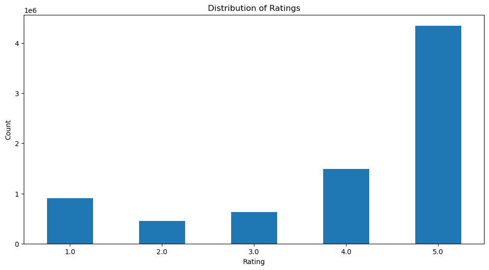

```python
import pandas as pd
import matplotlib.pyplot as plt

# Load the dataset with header=None to prevent first row from being treated as headers
df = pd.read_csv('ratings_Electronics.csv', header=None)

# Define the actual column names based on the dataset attributes
column_names = ['userId', 'productId', 'Rating', 'timestamp']

# Assign the correct column names to the DataFrame
df.columns = column_names

# Check the column names to verify they are correct
print("Column names in the dataset:", df.columns)

# Assuming 'Rating' is the correct column name based on dataset attributes
rating_column = 'Rating'  # Adjust if necessary based on actual column names

# Create the bar plot of rating distribution
plt.figure(figsize=(12, 6))
df[rating_column].value_counts().sort_index().plot(kind='bar')
plt.title('Distribution of Ratings')
plt.xlabel('Rating')
plt.ylabel('Count')
plt.xticks(rotation=0)
plt.show()
```

**Write your observations here: The output of the graph clearly shows that a rating of 5.0 has the maximum number of counts whereas products with a rating of 2.0 are less likely to occur compared to the other ratings.

### **Checking the number of unique users and items in the dataset**

```python
import pandas as pd

# Define the column names based on dataset attributes
column_names = ['userId', 'productId', 'Rating', 'timestamp']

# Load the dataset with specified column names
df = pd.read_csv('ratings_Electronics.csv', names=column_names)

# Check the column names to verify they are correct
print("Column names in the dataset:", df.columns)

# Calculate the number of unique users and items
num_obs = len(df)
num_unique_users = df['userId'].nunique()
num_unique_items = df['productId'].nunique()

# Print the results
print('The number of observations in the final data =', num_obs)
print('Number of unique USERS in Raw data =', num_unique_users)
print('Number of unique ITEMS in Raw data =', num_unique_items)
```

```
Column names in the dataset: Index(['userId', 'productId', 'Rating', 'timestamp'], dtype='object')
The number of observations in the final data = 7824482
Number of unique USERS in Raw data = 4201696
Number of unique ITEMS in Raw data = 476002
```

Write your observations here: The dataset includes the columns: userId, productId, Rating, and timestamp. It contains a total of 7,824,482 observations. Within this data, there are 4,201,696 unique users and 476,002 unique items. This indicates a wide range of user interactions and a diverse set of products, which is beneficial for building a comprehensive recommendation system.

### **Users with the most number of ratings**

```python
# Top 10 users based on the number of ratings
import pandas as pd

# Load the dataset with correct header names
df = pd.read_csv('ratings_Electronics.csv', names=['userId', 'productId', 'Rating', 'timestamp'])

# Check the column names to verify they are correct
print("Column names in the dataset:", df.columns)

# Assuming 'userId' and 'Rating' are the correct column names based on dataset attributes
user_rating_counts = df['userId'].value_counts()

# Find top 10 users with the most number of ratings
top_10_users = user_rating_counts.head(10)

# Print the top 10 users and their number of ratings
print("Top 10 users based on the number of ratings:")
print(top_10_users)
```

```
Column names in the dataset: Index(['userId', 'productId', 'Rating', 'timestamp'], dtype='object')
Top 10 users based on the number of ratings:
userId
A5JLAU2ARJ0BO     520
ADLVFFE4VBT8      501
A3OXHLG6DIBRW8    498
A6FIAB28IS79      431
A680RUE1FDO8B     406
A1ODOGXEYECQQ8    380
A36K2N527TXXJN    314
A2AY4YUOX2N1BQ    311
AWPODHOB4GFWL     308
ARBKYIVNYWK3C     296
Name: count, dtype: int64
```

Write your observations here: The dataset includes the columns: userId, productId, Rating, and timestamp. An analysis of user activity shows the top 10 users based on the number of ratings they have provided. The user with the most ratings is A5JLAU2ARJ0BO with 520 ratings, followed by ADLVFFE4VBT8 with 501 ratings, and A3OXHLG6DIBRW8 with 498 ratings. Other top users include A6FIAB28IS79 (431 ratings), A680RUE1FDO8B (406 ratings), A1ODOGXEYECQQ8 (380 ratings), A36K2N527TXXJN (314 ratings), A2AY4YUOX2N1BQ (311 ratings), AWPODHOB4GFWL (308 ratings), and ARBKYIVNYWK3C (296 ratings). This information highlights the most active users in terms of rating products within the dataset.

**Now that we have explored and prepared the data, let's build the first recommendation system.**